# Cleaning Networks 2_ Subgraphs

Tom Leppard

2025-02-17

```r
library(igraph)
```

Bringing in the data and cleaning out the self loops.

```r
grime_edge_list <- read.csv(file.choose(), header = TRUE)

grime_08 <- graph_from_data_frame(d= grime_edge_list, directed = TRUE)
```

```r
grime_08_clean <- delete_edges(grime_08, E(grime_08)[which_loop(grime_08)])
```

You may want to create subgraphs of the network that you have. There are two basic ways that you can think about this. You may be interested in a specific group of people and how they relate to each other, or you may be interested in a specific person and find out who they are connected to.

First, a subgraph to see a specific set of people and how/whether they are connected

You may have a list of individual nodes that you are interested in and you want to see how they related to each other. You can do this by creating a vector with the names of thise nodes, then use the subgraph function().

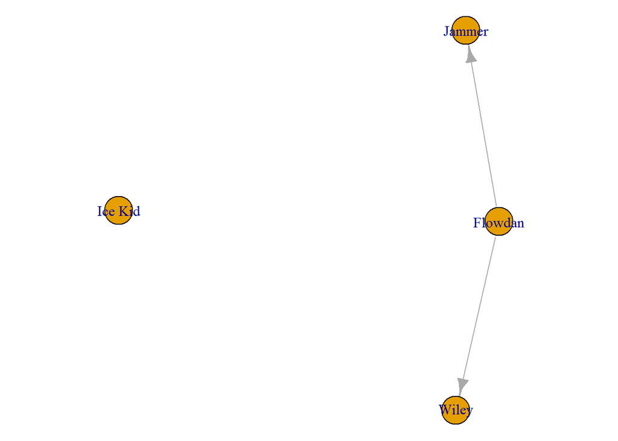

```r
sub_people <- c('Wiley', 'Jammer', 'Flowdan', 'Ice Kid')
sub_net <- subgraph(grime_08_clean, sub_people)
par(mar = c(0,0,0,0))
plot(sub_net)
```

Next, you may want to see ego networks from those in your network. In other words, smaller networks showing only the connections of each individual artist. To do this, you can use the make_ego_graph() argument. This creates a list of ego graphs from your entire network. Note, the order = 1 argument refers to the number of steps away from the ego (focal node). Since mine is set to 1, this only caputres the ego’s immidiate neighbours (i.e. only those directly connected to ego).

```r
ego_graphs <- make_ego_graph(grime_08_clean, order = 1)
head(ego_graphs)
```

```
## [[1]]
## IGRAPH 13f9b45 DN-- 2 1 --
## + attr: name (v/c), collab_weight (e/n)
## + edge from 13f9b45 (vertex names):
## [1] Asher D->Wiley
##
## [[2]]
## IGRAPH 13f9b5d DN-- 1 0 --
## + attr: name (v/c), collab_weight (e/n)
## + edges from 13f9b5d (vertex names):
##
## [[3]]
## IGRAPH 13f9b67 DN-- 1 0 --
## + attr: name (v/c), collab_weight (e/n)
## + edges from 13f9b67 (vertex names):
##
## [[4]]
## IGRAPH 13f9b71 DN-- 2 1 --
## + attr: name (v/c), collab_weight (e/n)
## + edge from 13f9b71 (vertex names):
## [1] Scorcher->Wiley
##
## [[5]]
## IGRAPH 13f9b7a DN-- 3 2 --
## + attr: name (v/c), collab_weight (e/n)
## + edges from 13f9b7a (vertex names):
## [1] Bless Beats->Wiley     Bless Beats->Roll Deep
##
## [[6]]
## IGRAPH 13f9b84 DN-- 3 2 --
## + attr: name (v/c), collab_weight (e/n)
## + edges from 13f9b84 (vertex names):
## [1] Flowdan->Wiley  Flowdan->Jammer
```

You can also specify exactly which node’s network you want to see. Let’s say there was a person of interest in your network that you specifically want to see. To do this, you can do the folliwing using the node’s name to single them out.

This chunk returns a lsit of edges connected to Wiley (the name of my node of interest).

```r
E(grime_08_clean)[[.inc('Wiley')]]
```

```
## + 8/28 edges from 13ec0ac (vertex names):
##              tail         head tid hid collab_weight
## 1         Asher D        Wiley   1  29             1
## 2        Scorcher        Wiley   4  29             4
## 3     Bless Beats        Wiley   5  29             1
## 4         Flowdan        Wiley   6  29             3
## 5  Tinchy Stryder        Wiley   7  29             2
## 6          Frisco        Wiley   8  29             1
## 7            Kano        Wiley   9  29             1
## 27          Wiley Lauren Mason  29  39             1
```

I can also plot these. To do so, I make an object with the name ‘Wiley’ and then make an ego graph based on that name only. The [[1]] simply tells R to get only the first one in the list that make_ego_graph() creates. In this case, Wiley.

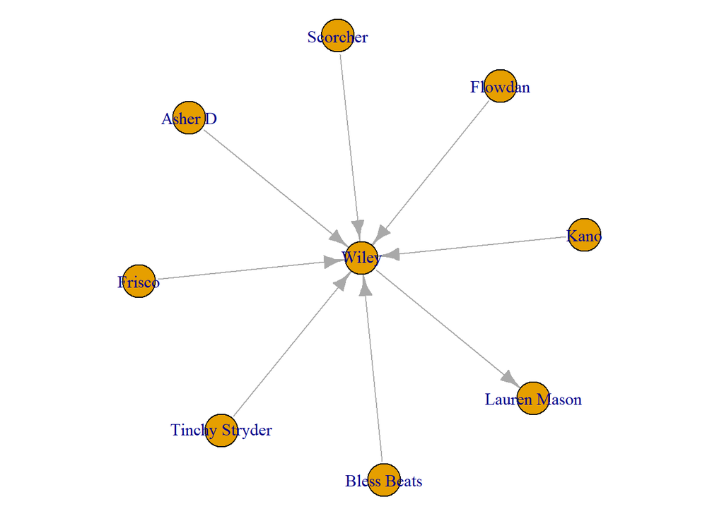

```r
Wiley <- "Wiley"
ego_wiley <- make_ego_graph(grime_08_clean, order = 1, nodes = Wiley)[[1]]

par(mar = c(0,0,0,0))
plot(ego_wiley)
```

You can also select an ego network with more information. The second order ego network includes the connections of Wiley’s neighbours.

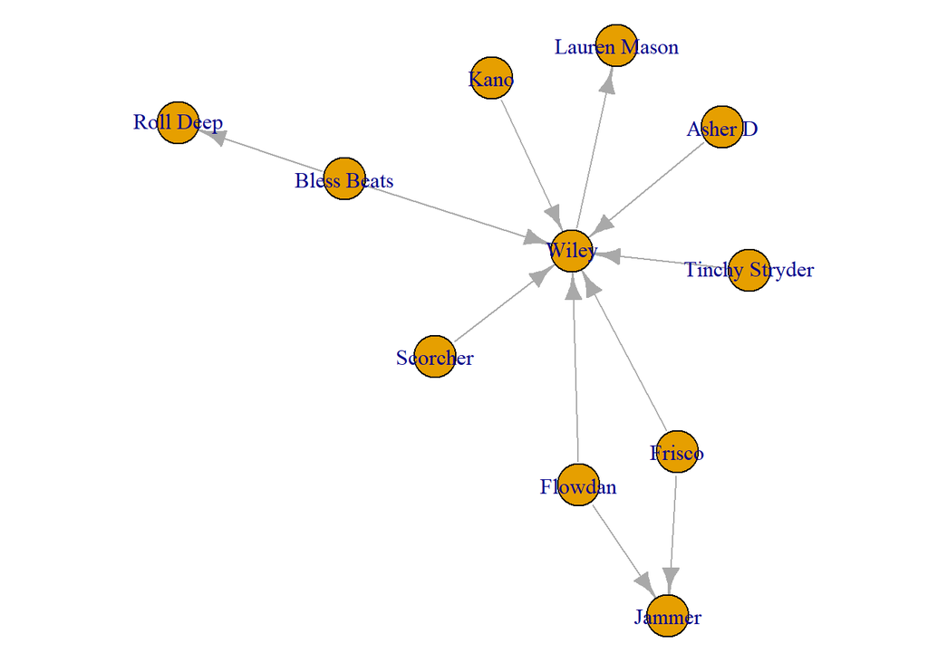

```r
second_order_wiley <- make_ego_graph(grime_08_clean, order = 2, nodes = Wiley)[[1]]

par(mar = c(0,0,0,0))
plot(second_order_wiley)
```

Pro tip: If you are working with ego networks like this, especially when you get passed the first order network (including friends of friends) it is good practice to do something to differentiate the ego from their neighbours. Once simple way it to change their colour.

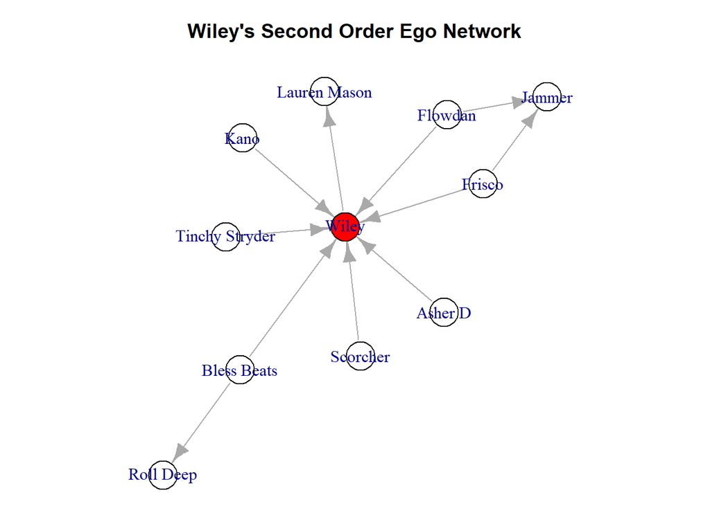

```r
V(second_order_wiley)$ego <- ifelse(V(second_order_wiley)$name %in% c("Wiley"), "red", "white")

par(mar = c(0,0,3,0))
plot(second_order_wiley, vertex.color = V(second_order_wiley)$ego, main = "Wiley's Second Order Ego Network")
```

Finally, one other way to can subset a network is by a set parameter you may have. For example, you may want to see a network of frequent collaborators (more than 1 collab).

The following returns a vector with collaborators who work together more than once.

```r
frequent_collabors <- E(grime_08_clean)[[collab_weight > 1]]
frequent_collabors
```

```
## + 8/28 edges from 13ec0ac (vertex names):
##              tail   head tid hid collab_weight
## 2        Scorcher  Wiley   4  29             4
## 4         Flowdan  Wiley   6  29             3
## 5  Tinchy Stryder  Wiley   7  29             2
## 8          Blacks Jammer  12  35             4
## 9         Badness Jammer  13  35             5
## 11        Tempa T Jammer  15  35             2
## 14         Skepta Jammer  17  35             5
## 16         Frisco Jammer   8  35             3
```

You can then turn this vector of edges into a igraph object to plot

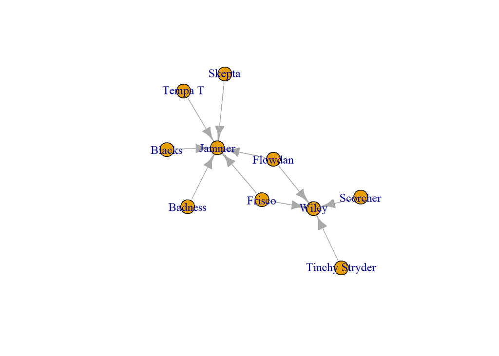

```r
frequent_collabors_graph <- induced_subgraph(grime_08_clean, vids = unique(c(ends(grime_08_clean, frequent_collabors)[, 1], ends(grime_08_clean, frequent_collabors)[, 2])))
plot(frequent_collabors_graph)
```